# Animals

By Hasan Arcas

12/30/2021

# **This is my final project’s markdown, it will be about my favorite topic in the whole world, Animals!!**

### Firstly, we call all the libraries we are gone to use:

```r
library(tidyverse)
library(ggthemes)
library(showtext)
library(scales)

font_add_google("Schoolbell", "bell")
showtext_auto()
```

#### I decided to use the “bell” font-style from the “Schoolbell” font-family for my plots’ texts.

### Here there is the code written in order to scrape all the data that I need from the website ‘https://a-z-animals.com/animals/’

#### All the code is commented out, because it would take a lot of time in order to scrape all the data

```r
# link <- "https://a-z-animals.com/animals/"
# page <- read_html(link)
#
# animals_list <- page %>%
#   html_nodes(".col-sm-6") %>%
#   html_text()
#
# get_animal_link <- function(animals_list){
#   animal_page <- paste(link, animals_list, sep="") %>%
#     gsub(" ", "-", ., fixed = T) %>%
#     tolower()
#   return(animal_page)
# }
#
# links <- sapply(animals_list[0:35],get_animal_link,USE.NAMES = F)
#
# animals <- data.frame(matrix(ncol = 7, nrow = 0))
# col_names <- c("Kingdom", "Phylum", "Class", "Order", "Family", "Genus", "Scientific Name")
# colnames(animals) <- col_names
#
# get_animal_features <- function(link){
#   if (url.exists(link)){
#     new_page <- read_html(link)
#     features <- new_page %>%
#       html_nodes(".col-sm-9") %>%
#       html_text()
#     if (length(features) == 7 ) {
#       animals[nrow(animals) + 1,] = features
#     }
#   }
#   print(link)
#   return(animals)
# }
#
# animals <- t(sapply(links, get_animal_features, USE.NAMES = F))
#
# animals_df <- as.data.frame(animals) %>%
#   apply( 2, as.character)
# write.csv(animals_df, "taxonomy.csv")
```

### We prepare our data by loading it to our working environment.

```r
animals <- read.csv("./datasets/taxonomy.csv")
animals <- animals[2:8]

for (row in c(1:nrow(animals))) {
  if(animals[row,1] == "logical(0)"){
    animals <- animals[-row, ]
  }
}
knitr::kable(head(animals), format = "markdown")
```

| Kingdom | Phylum | Class | Order | Family | Genus | Scientific.Name |
| --- | --- | --- | --- | --- | --- | --- |
| Animalia | Chordata | Mammalia | Tubulidentata | Orycteropodidae | Orycteropus | Orycteropus afer |
| Animalia | Chordata | Mammalia | Carnivora | Felidae | Felis | Felis catus |
| Animalia | Chordata | Mammalia | Artiodactyla | Bovidae | Addax | Addax nasomaculatus |
| Animalia | Chordata | Aves | Sphenisciformes | Spheniscidae | Pygoscelis | Pygoscelis adeliae |
| Animalia | Chordata | Mammalia | Carnivora | Canidae | Canis | Canis Lupus |
| Animalia | Chordata | Mammalia | Carnivora | Canidae | Canis | Canis Lupus |

#### There were some minor errors while scraping the data (some data came damages for some reasons) so I decided to eliminate them directly.

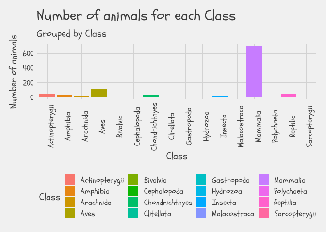

```r
animals %>%
  ggplot(aes(x = Class, fill= Class))+
  geom_bar()+
  labs(title = "Number of animals for each Class",
       subtitle = "Grouped by Class",
       y = "Number of animals",
       x = "Class")+
  theme_fivethirtyeight()+
  theme(axis.title = element_text(), text = element_text(family = "bell", size = 15), axis.text.x = element_text(angle = 90))
```

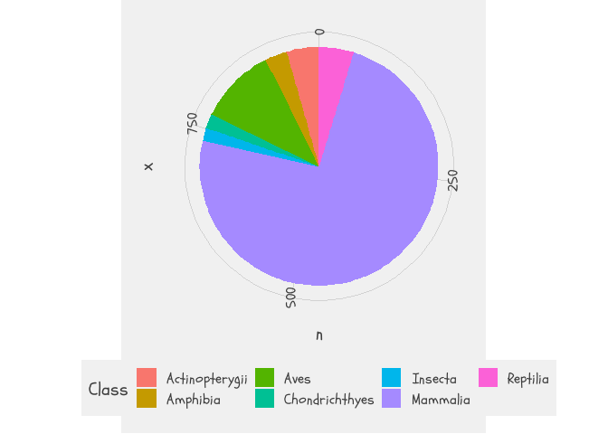

```r
class_gruped <- animals %>% count(Class, sort = T) %>%
  mutate(percentages= round(n / 936, 2))

class_gruped[1:7,] %>%
  ggplot(aes(x="", y=n, fill= Class))+
  geom_bar(width = 1, stat = "identity")+
  coord_polar("y", start=0)+
  theme_fivethirtyeight()+
  theme(axis.title = element_text(), text = element_text(family = "bell", size = 15), axis.text.x = element_text(angle = 90))
```

#### The bar chart shows the number of the members of each class, the pie chart shows only the first 7 classes because it would be a mess to show all the classes with low member numbers.

#### By looking at this barplot and pie chart we can easily say that most of our animals are part of the phylum called Chordata, which is a phylum of animals that includes the vertebrates together with the sea squirts and lancelets.

### Number of animals for each Class

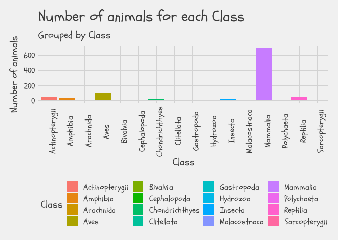

```r
animals %>%
  ggplot(aes(x = Class, fill= Class))+
  geom_bar()+
  labs(title = "Number of animals for each Class",
       subtitle = "Grouped by Class",
       y = "Number of animals",
       x = "Class")+
  theme_fivethirtyeight()+
  theme(axis.title = element_text(), text = element_text(family = "bell", size = 15), axis.text.x = element_text(angle = 90))
```

```r
mammals <- filter(animals, Class == "Mammalia")
```

#### After noticing that most of our animals are Mammals, I decided to look specifically to this class from now on.

### Number of animals grouped by Order

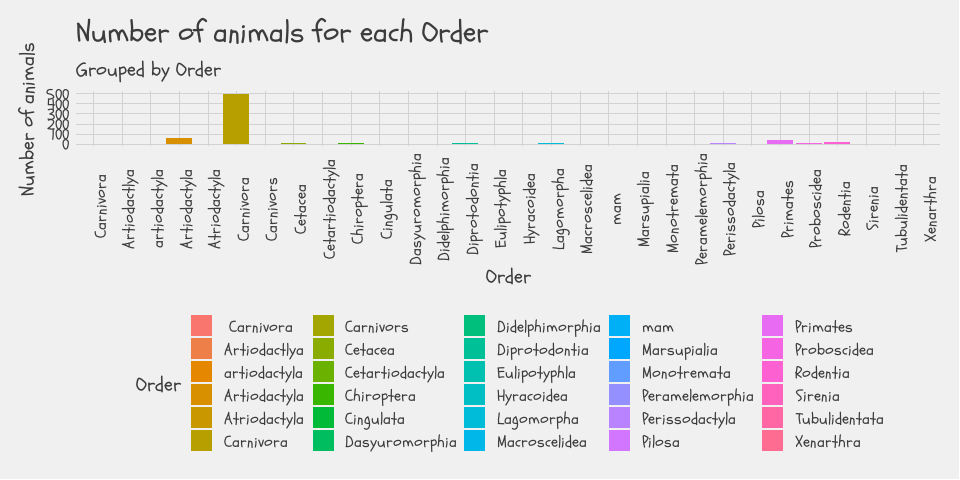

```r
mammals %>%
  ggplot(aes(x= Order, fill= Order))+
  geom_bar()+
  labs(title = "Number of animals for each Order",
       subtitle = "Grouped by Order",
       y = "Number of animals",
       x = "Order")+
  theme_fivethirtyeight()+
  theme(axis.title = element_text(), text = element_text(family = "bell", size = 15), axis.text.x = element_text(angle = 90))
```

```r
mammals$Order[mammals$Order == " Carnivora" | mammals$Order == "Carnivors"] <- "Carnivora"
mammals$Order[mammals$Order == "Artiodactlya"| mammals$Order == "Atriodactyla"] <- "Artiodactyla"
```

#### The first thing that we notice by looking at this plot, is that the Order Carnivora is the most common one in our dataset, but we can notice something else if we look more carefully to our legend.

#### Some of the Orders are misspelled, this leads to having a dirty data so that’s why I tried to fix that in the last 2 lines.

#### At this point we should ask ourselves, does this problem occurs elsewhere?

### Checking problems in Scientific Names

```r
summary <- mammals %>%
  count(Scientific.Name, sort = T)
knitr::kable(head(summary), format = "markdown")
```

| Scientific.Name | n |
| --- | --- |
| Canis lupus | 323 |
| Canis Lupus | 44 |
| Felis catus | 23 |
| Capra aegagrus hircus | 11 |
| Canis lupus familiaris | 5 |
| Vulpes vulpes | 4 |

```r
mammals$Scientific.Name[mammals$Scientific.Name == "Canis lupus" | mammals$Scientific.Name == "Canis lupus familiaris"] <- "Canis Lupus"
```

#### A similar problem occured for the Canis Lupus Scientific Name.

#### Making this types of checks is really important, because there is dirty data everywhere, which is waiting to be cleaned…

# **From now on we will continue with another dataset, and we will focus more on machine learning algorithms, rather than data exploratory analysis**

### As usual, we call all the libraries we are gone to use before starting our projects

```r
library(caret)
library(randomForest)
library(mice)
library(nnet)
library(smotefamily)
library(ggfortify)
library(reshape2)
library(ggfortify)
```

### Data import and first preparations

```r
crabs_df <- read.csv("./datasets/CrabAgePrediction.csv")

colnames(crabs_df)[6] <- "Shucked Weight"
colnames(crabs_df)[7] <- "Viscera Weight"
colnames(crabs_df)[8] <- "Shell Weight"

foot_to_cm <- 30.48
ounce_to_kg <- 0.0283495

crabs_df$Length <- crabs_df$Length * foot_to_cm
crabs_df$Diameter <- crabs_df$Diameter * foot_to_cm
crabs_df$Height <- crabs_df$Height * foot_to_cm
crabs_df$Weight <- crabs_df$Weight * ounce_to_kg
crabs_df$`Shucked Weight` <- crabs_df$`Shucked Weight` * ounce_to_kg
crabs_df$`Viscera Weight` <- crabs_df$`Viscera Weight` * ounce_to_kg
crabs_df$`Shell Weight` <- crabs_df$`Shell Weight` * ounce_to_kg

knitr::kable(head(crabs_df), format = "markdown")
```

| Sex | Length | Diameter | Height | Weight | Shucked Weight | Viscera Weight | Shell Weight | Age |
| --- | --- | --- | --- | --- | --- | --- | --- | --- |
| F | 43.815 | 35.814 | 12.573 | 0.6984102 | 0.3496070 | 0.1583277 | 0.1912792 | 9 |
| M | 27.051 | 19.812 | 6.477 | 0.1531037 | 0.0650992 | 0.0389792 | 0.0442032 | 6 |
| I | 31.623 | 23.622 | 7.620 | 0.2254362 | 0.0916211 | 0.0454087 | 0.0783602 | 6 |
| F | 35.814 | 27.051 | 7.620 | 0.3821566 | 0.1346188 | 0.0646974 | 0.1486834 | 10 |
| I | 27.051 | 20.193 | 6.477 | 0.1956995 | 0.0980507 | 0.0421939 | 0.0482216 | 6 |
| F | 47.244 | 35.433 | 10.668 | 0.8125348 | 0.3849695 | 0.1916811 | 0.2049420 | 8 |

#### I fixed some of the column names, and because all the values were in imperial system (foot and ounce) I converted all the values to a more comprehensible system, the only right system which is the metric one.

### Choosing the right subset of our data

#### I’ve chosen to not work with all the data, because similar works were done with the same data. That’s why I’ve decided to take a smaller subset of the data to work on.

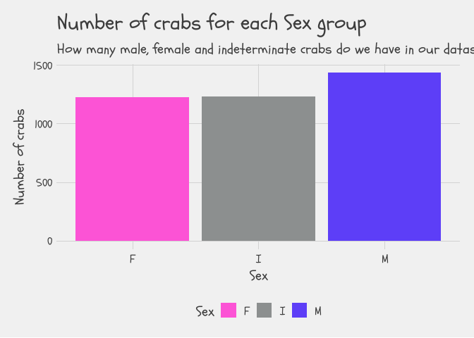

```r
crabs_df %>%
  ggplot(aes(x = Sex, fill= Sex))+
  geom_bar() +
  scale_fill_manual(values= c("#fc53d5", "#8c8f8f","#5d3ef7"))+
  labs(title = "Number of crabs for each Sex group",
       subtitle = "How many male, female and indeterminate crabs do we have in our dataset?",
       y = "Number of crabs",
       x = "Sex")+
  theme_fivethirtyeight()+
  theme(axis.title = element_text(), text = element_text(family = "bell", size = 15))
```

```r
m_crab <- filter(crabs_df, Sex == "M")
```

#### In order to choose the data I’ve decided to take the crabs based on one Sex, it looks like the group that occurs more is the male group, so let’s take all the male crabs.

### Weight Distribution

#### I know I said that this part will be more focused on machine learning, but this chart is too cute not to be added here….

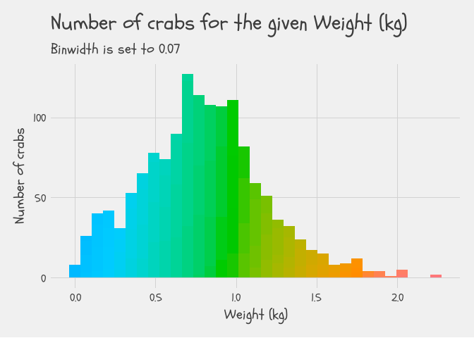

```r
m_crab %>%
  ggplot(aes(x = Weight,  fill=cut(Weight, 100))) +
  geom_histogram( binwidth = 0.07, show.legend = F) +
  scale_fill_discrete(h = c(240, 10), c = 120, l = 70)+
  labs(title = "Number of crabs for the given Weight (kg)",
       subtitle = "Binwidth is set to 0.07",
       x = "Weight (kg)",
       y = "Number of crabs")+
  theme_fivethirtyeight()+
  theme(axis.title = element_text(),  text = element_text(family = "bell", size = 15))
```

### Trying to see if there is correlation

[figure not shown]

```r
m_crab %>%
  ggplot(aes(x = Length, y = Diameter, color = Weight))+
  geom_point() +
  scale_color_gradientn(colors= rainbow(5)) +
  labs(title="Diameter Vs Length Vs Height",
       subtitle = "Scatter plot of how Diameter and Height change based on the Length of Male crabs",
       y = "Diameter (cm)",
       x = "Lenght (cm)")+
  theme_fivethirtyeight()+
  theme(axis.title = element_text(), text = element_text(family = "bell", size = 15))
```

#### So maybe it will be wise to plot a heatmap in order to visualize the correlation between the attributes

### Drawing a heatmap

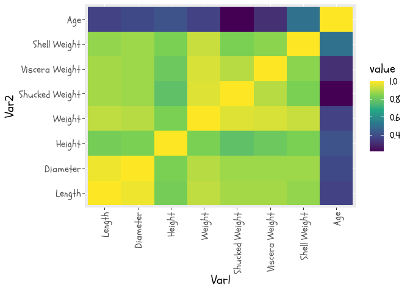

```r
res <- round(cor(m_crab[2:9]), 2)
melted_corr <- melt(res)
ggplot(melted_corr, aes(Var1, Var2, fill=value)) +
  guides(x =  guide_axis(angle = 90)) +
  scale_fill_continuous(type = "viridis")+
  geom_tile()+
  theme(axis.title = element_text(), text = element_text(family = "bell", size = 15))
```

#### Is it as clear as the day that all the attributes are somehow related with eachother, so maybe it would be a good idea to work with principal components.

#### But we should try to work without PC first, in order to see how our results will change

### Linear Regression with original data

```r
set.seed(42)
crab_X <- m_crab[2:8]
crab_y <- m_crab[9]
test_inds <- createDataPartition(crab_y$Age, p=0.2, list=F)
crab_train_data <- m_crab[-test_inds,2:9]
crab_test_data_X <- m_crab[test_inds, 2:8]
crab_test_data_y <- m_crab[test_inds, 9]
fit <- lm(Age ~ .,data = crab_train_data)
predictions <- fit %>% predict(crab_test_data_X)
RMSE(predictions, crab_test_data_y)
```

```
## [1] 2.218935
```

#### I used RMSE (Root Mean Square Error) as the measure of the performance of our linear regression model

#### Now let’s try to create a model with principal components

### PCA

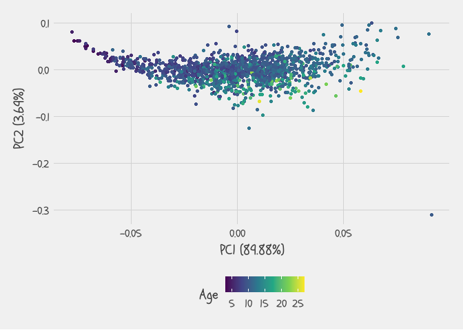

```r
PCA <- prcomp(crab_X, scale. = T, center = T)

autoplot(PCA, data = m_crab, colour= "Age")+
  theme_fivethirtyeight()+
  theme(axis.title = element_text(), text = element_text(family = "bell", size = 15))+
  scale_color_continuous(type = "viridis")
```

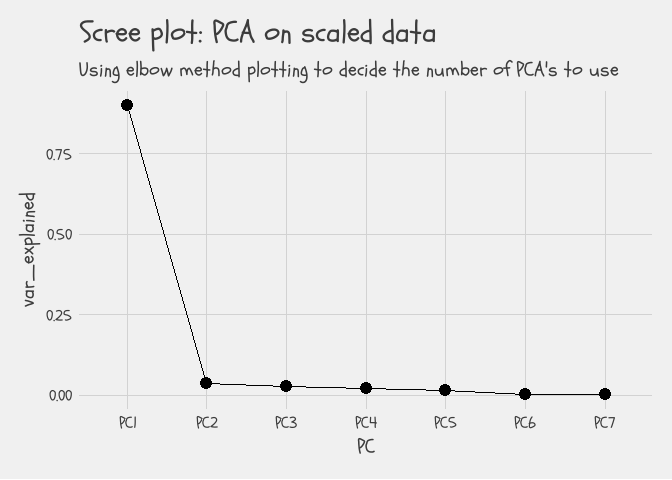

```r
var_explained_df <- data.frame(PC = paste0("PC", 1:7), var_explained = (PCA$sdev)^2 / sum((PCA$sdev)^2))
var_explained_df %>%
  ggplot(aes(x=PC,y=var_explained, group=1))+
  geom_point(size=4)+
  geom_line()+
  labs(title="Scree plot: PCA on scaled data",
       subtitle = "Using elbow method plotting to decide the number of PCA's to use")+
  theme_fivethirtyeight()+
  theme(axis.title = element_text(), text = element_text(family = "bell", size = 15))
```

```r
summary(PCA)
```

```
## Importance of components:
##                           PC1     PC2     PC3     PC4     PC5     PC6     PC7
## Standard deviation     2.5083 0.50837 0.43342 0.38391 0.29826 0.13138 0.09352
## Proportion of Variance 0.8988 0.03692 0.02684 0.02106 0.01271 0.00247 0.00125
## Cumulative Proportion  0.8988 0.93568 0.96252 0.98358 0.99628 0.99875 1.00000
```

#### We can easily see that 1 or 2 principal components explain most of the data, so we chose to take just the first 2 components (which explain %94 of the data)

### Linear Regression with PCs

```r
pca <- as.data.frame(PCA$x[, 1:2])
pca$Age <- m_crab$Age
set.seed(101)
crab_train_pca <- pca[-test_inds,]
crab_test_pca <- pca[test_inds,]
fit_pca <- lm(Age~ ., data= crab_train_pca)
new_predictions <- fit_pca %>% predict(crab_test_pca)
RMSE(new_predictions, crab_test_pca$Age)
```

```
## [1] 2.503937
```

#### Well that was unexpected, we used PCA because there was correlation between our attributes, but the RMSE incresed from 2.21 to 2.50 (smaller RMSE means more accurate model).

#### So this explains that there are not stric rules in machine learning, applying PCA will not always boost the performans of your model.

### Data imputation

#### From now on I started to use the original crabs data (not only the male ones) , because I’m gone to manually change it again.

```r
no_of_NA <- 10000
crab_convert_to_na <- crabs_df[2:9]

for(i in c(1:no_of_NA)){
  crab_convert_to_na[sample(nrow(crab_convert_to_na),1), sample(ncol(crab_convert_to_na), 1)] <- NA
}

crabs_df_deleted <- as.data.frame(c(crabs_df[1], crab_convert_to_na))
sum(is.na(crabs_df_deleted))
```

```
## [1] 8530
```

#### My data had 0 NA values, so in order to make data imputation I randomly cancelled some values. Now there are between 8000-9000 NA values.

#### It’s time to see if data imputation affects our model’s performance.

#### Classification with missing values

```r
crabs_df$Sex <- as.factor(crabs_df_deleted$Sex)
crabs_omitted <- na.omit(crabs_df_deleted)
set.seed(123)
crabs_X <- crabs_omitted[2:9]
crabs_y <- crabs_omitted[1]
test_inds <- createDataPartition(crabs_y$Sex, p=0.2, list=F)
crab_train_data <- crabs_omitted[-test_inds,]
crab_test_data_X <- crabs_omitted[test_inds, 2:9]
crab_test_data_y <- crabs_omitted[test_inds, 1]

fit.deleted <- multinom(Sex ~ ., crab_train_data)
predictions.deleted <- predict(fit.deleted, crab_test_data_X)

confusion_deleted <- table(predictions.deleted, crab_test_data_y)
acc_deleted <- sum(diag(confusion_deleted)) / sum(confusion_deleted)
precison_deleted <- diag(confusion_deleted) / rowSums(confusion_deleted)
recall_deleted <- diag(confusion_deleted) / colSums(confusion_deleted)
```

#### Classification with imputed values

```r
imputed_crabs <- mice(crabs_df_deleted, m=5, maxit = 50, method = "pmm", seed= 42)
imputed_crabs_df <- complete(imputed_crabs, 2)
set.seed(123)
crabs_X <- imputed_crabs_df[2:9]
crabs_y <- imputed_crabs_df[1]

test_inds <- createDataPartition(crabs_y$Sex, p=0.2, list=F)
crab_train_data <- imputed_crabs_df[-test_inds,]
crab_test_data_X <- imputed_crabs_df[test_inds, 2:9]
crab_test_data_y <- imputed_crabs_df[test_inds, 1]

fit.imputed <- multinom(Sex ~ ., crab_train_data)
predictions.imputed <- predict(fit.imputed, crab_test_data_X)

confusion_imputed <- table(predictions.imputed, crab_test_data_y)
acc_imputed <- sum(diag(confusion_imputed)) / sum(confusion_imputed)
precison_imputed <- diag(confusion_imputed) / rowSums(confusion_imputed)
recall_imputed <- diag(confusion_imputed) / colSums(confusion_imputed)
```

#### I used multinomial logistic regression as my classification algorithm and used Accuracy, Precision and Recall to compare the performance of each model.

#### Performance Comparison of missing vs imputed:

```r
comparison.accuracy <- t(data.frame(acc_deleted, acc_imputed))
colnames(comparison.accuracy) <- "Accuracy"
comparison.precision <- t(data.frame(precison_deleted, precison_imputed))
comparison.recall <- t(data.frame(recall_deleted, recall_imputed))
knitr::kable(comparison.accuracy, format = "markdown")
```

|  | Accuracy |
| --- | --- |
| acc_deleted | 0.5373134 |
| acc_imputed | 0.5430039 |

```r
knitr::kable(comparison.precision, format = "markdown")
```

|  | F | I | M |
| --- | --- | --- | --- |
| precison_deleted | 0.5625000 | 0.5000000 | 0.6000000 |
| precison_imputed | 0.4480874 | 0.6417445 | 0.4909091 |

```r
knitr::kable(comparison.recall, format = "markdown")
```

|  | F | I | M |
| --- | --- | --- | --- |
| recall_deleted | 0.6923077 | 0.8333333 | 0.1304348 |
| recall_imputed | 0.3346939 | 0.8340081 | 0.4703833 |

### Dealing with Imbalanced Data

```r
table(crabs_df$Sex)
```

```
##
##    F    I    M
## 1225 1233 1435
```

```r
imbalanced_crabs <- crabs_df[-sample(which(crabs_df[, "Sex"] == "F"), 1000),]
table(imbalanced_crabs$Sex)
```

```
##
##    F    I    M
##  225 1233 1435
```

#### Classification with imbalanced data

```r
set.seed(1234)
crabs_X <- imbalanced_crabs[2:9]
crabs_y <- imbalanced_crabs[1]
test_inds <- createDataPartition(crabs_y$Sex, p=0.2, list=F)
crab_train_data <- imbalanced_crabs[-test_inds,]
crab_test_data_X <- imbalanced_crabs[test_inds, 2:9]
crab_test_data_y <- imbalanced_crabs[test_inds, 1]

fit.imbalanced <- multinom(Sex ~ ., crab_train_data)
predictions_imbalanced <- predict(fit.imbalanced, crab_test_data_X)

confusion_imbalanced <- table(predictions_imbalanced, crab_test_data_y)
acc_imbalanced <- sum(diag(confusion_imbalanced)) / sum(confusion_imbalanced)
precison_imbalanced <- diag(confusion_imbalanced) / rowSums(confusion_imbalanced)
recall_imbalanced <- diag(confusion_imbalanced) / colSums(confusion_imbalanced)
```

#### Oversampling the data using SMOTE

```r
oversampled_crabs <- SMOTE(imbalanced_crabs[2:9], imbalanced_crabs[1], dup_size = 4, )
oversampled_crabs$data$class <- as.factor(oversampled_crabs$data$class)
rename(oversampled_crabs$data, Sex = class)
```

```r
table(oversampled_crabs$data$class)
```

```
##
##    F    I    M
## 1125 1233 1435
```

#### Classification with oversampled data

```r
set.seed(1234)
crabs_X <- oversampled_crabs$data[1:8]
crabs_y <- oversampled_crabs$data[9]
test_inds <- createDataPartition(crabs_y$class, p=0.2, list=F)
crab_train_data <- oversampled_crabs$data[-test_inds,]
crab_test_data_X <- oversampled_crabs$data[test_inds, 1:8]
crab_test_data_y <- oversampled_crabs$data[test_inds, 9]

fit <- multinom(class ~ ., crab_train_data)
predictions_oversampled <- predict(fit, crab_test_data_X)

confusion_oversampled <- table(predictions_oversampled, crab_test_data_y)
acc_oversampled <- sum(diag(confusion_oversampled)) / sum(confusion_oversampled)
precison_oversampled <- diag(confusion_oversampled) / rowSums(confusion_oversampled)
recall_oversampled <- diag(confusion_oversampled) / colSums(confusion_oversampled)
```

#### I again used multinomial logistic regression as my classification algorithm and used Accuracy, Precision and Recall to compare the performance of each model.

#### Performance Comparison between imbalanced vs oversampled:

```r
comparison.accuracy <- t(data.frame(acc_imbalanced, acc_oversampled))
colnames(comparison.accuracy) <- "Accuracy"
comparison.precision <- t(data.frame(precison_imbalanced, precison_oversampled))
comparison.recall <- t(data.frame(recall_imbalanced, recall_oversampled))
knitr::kable(comparison.accuracy, format = "markdown")
```

|  | Accuracy |
| --- | --- |
| acc_imbalanced | 0.7150259 |
| acc_oversampled | 0.5375494 |

```r
knitr::kable(comparison.precision, format = "markdown")
```

|  | F | I | M |
| --- | --- | --- | --- |
| precison_imbalanced | NaN | 0.7191011 | 0.7115385 |
| precison_oversampled | 0.4418605 | 0.6476510 | 0.4759036 |

```r
knitr::kable(comparison.recall, format = "markdown")
```

|  | F | I | M |
| --- | --- | --- | --- |
| recall_imbalanced | 0.0000000 | 0.7773279 | 0.7735192 |
| recall_oversampled | 0.2533333 | 0.7813765 | 0.5505226 |

#### Even it’s accuracy is decreased, we should use the oversampled data because the accuracy of the imbalanced data is a little tricky.

#### The accuracy seems high for the imbalanced data, but it is liked that only because it never respond as “F”, we can see that from precision and recall.

# **For the last part of the project I will change the data I’m using one more time**

### We call the extra library that we are gone to use

```r
library(janitor)
library(randomForest)
library(class)
library(rpart)
library(rpart.plot)
library(factoextra)
```

### Data import and first preparations

```r
zoo <- read.csv("./datasets/zoo.csv")
class_types <- c("Mammal", "Bird", "Reptile", "Fish", "Amphibian", "Bug", "Invertebrate")

for (variable in zoo$class_type){
  zoo$class_type[zoo$class_type == variable] <- class_types[variable]
}
zoo$class_type <- as.factor(zoo$class_type)
zoo_to_show <- cbind(zoo[1:11], zoo[18])
knitr::kable(head(zoo_to_show), format = "markdown")
```

| animal_name | hair | feathers | eggs | milk | airborne | aquatic | predator | toothed | backbone | breathes | class_type |
| --- | --- | --- | --- | --- | --- | --- | --- | --- | --- | --- | --- |
| aardvark | 1 | 0 | 0 | 1 | 0 | 0 | 1 | 1 | 1 | 1 | Mammal |
| antelope | 1 | 0 | 0 | 1 | 0 | 0 | 0 | 1 | 1 | 1 | Mammal |
| bass | 0 | 0 | 1 | 0 | 0 | 1 | 1 | 1 | 1 | 0 | Fish |
| bear | 1 | 0 | 0 | 1 | 0 | 0 | 1 | 1 | 1 | 1 | Mammal |
| boar | 1 | 0 | 0 | 1 | 0 | 0 | 1 | 1 | 1 | 1 | Mammal |
| buffalo | 1 | 0 | 0 | 1 | 0 | 0 | 0 | 1 | 1 | 1 | Mammal |

```r
zoo_total <- zoo_to_show %>% adorn_totals("row")
knitr::kable(tail(zoo_total, n=1), format = "markdown")
```

|  | animal_name | hair | feathers | eggs | milk | airborne | aquatic | predator | toothed | backbone | breathes | class_type |
| --- | --- | --- | --- | --- | --- | --- | --- | --- | --- | --- | --- | --- |
| 102 | Total | 43 | 20 | 59 | 41 | 24 | 36 | 56 | 61 | 83 | 80 | - |

#### I changed the target column of my data, originally it was from 1 to 7 where each number represents a class, now each class is represented by the appropriate name.

#### I used zoo_to_show and omitted some columns because it was to large and did not fit on the screen.

#### I added a last row where there is the sum of the occurences for each feature

### Search for correlation between features

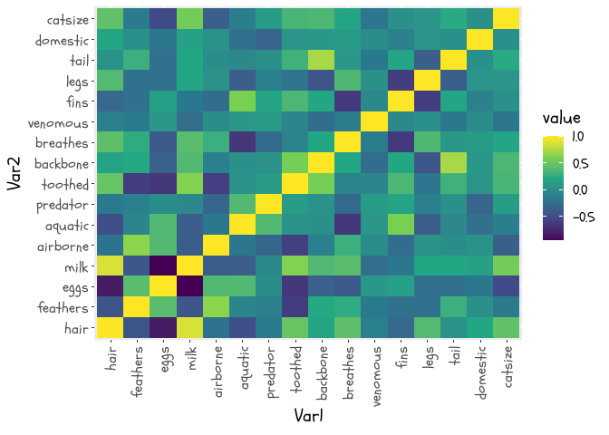

```r
res <- round(cor(zoo[2:17]), 2)
melted_corr <- melt(res)
ggplot(melted_corr, aes(Var1, Var2, fill=value)) +
  scale_fill_continuous(type = "viridis")+
  guides(x =  guide_axis(angle = 90)) +
  geom_tile()+
  theme(axis.title = element_text(), text = element_text(family = "bell", size = 15))
```

#### So it’s better to directly move on and apply our algorithms to the original data.

### Classification algorithms

#### I’ve decided to use decision tree and random forest as my classification algorithms.

#### The reason to choose these 2 algorithms is because one consists of the other, so I was curious about the final results.

#### Decision Tree Classifier

```r
set.seed(42)
test_inds <- createDataPartition(zoo$class_type, p=0.2, list=F)
zoo_train_data <- zoo[-test_inds, 2:18]
zoo_test_data_X <- zoo[test_inds, 2:17]
zoo_test_data_y <- zoo[test_inds, 18]

fit.tree <- rpart(class_type ~., zoo_train_data, method = "class")
```

#### We cab plot the tree structure to see how the model ‘thinks’.

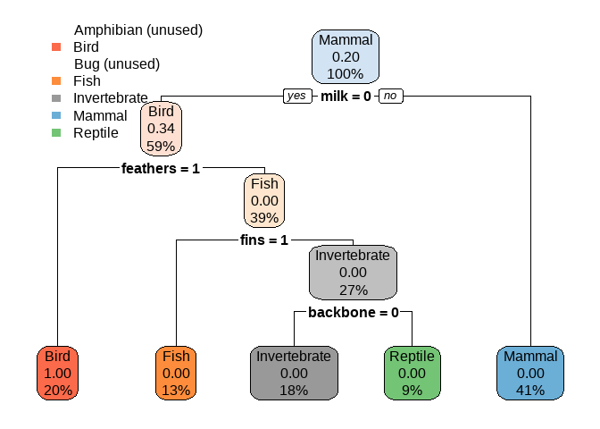

```r
rpart.plot(fit.tree, extra = 106)
```

```r
predictions_tree <- predict(fit.tree, zoo_test_data_X, type = "class")
confusion_tree <- table(predictions_tree, zoo_test_data_y)
acc_tree <- sum(diag(confusion_tree)) / sum(confusion_tree)
precison_tree <- diag(confusion_tree) / rowSums(confusion_tree)
recall_tree <- diag(confusion_tree) / colSums(confusion_tree)
```

#### Now let’s try to use a Random Forest Classifier and after that let’s compare the results.

#### Random Forest Classifier

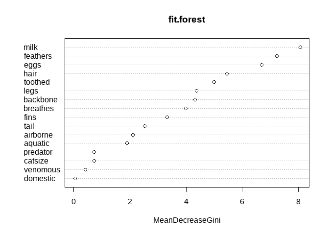

```r
fit.forest <- randomForest(class_type ~., data = zoo_train_data)
varImpPlot(fit.forest)
```

```r
prediction_forest <- predict(fit.forest, zoo_test_data_X)
confusion_forest <- table(prediction_forest, zoo_test_data_y)
acc_forest <- sum(diag(confusion_forest)) / sum(confusion_forest)
precison_forest <- diag(confusion_forest) / rowSums(confusion_forest)
recall_forest <- diag(confusion_forest) / colSums(confusion_forest)
```

#### By using varImpPlot() we can plot the Mean Decrease Gini for each feature, greater value means more importance in terms of reaching the target variable.

#### So we can see that the model will most probabily use milk, eggs or feathers variables as root note for each tree.

#### Performance comparison between Tree and Random Forest classifiers

```r
comparison.accuracy <- t(data.frame(acc_tree, acc_forest))
colnames(comparison.accuracy) <- "Accuracy"
comparison.precision <- t(data.frame(precison_tree, precison_forest))
comparison.recall <- t(data.frame(recall_tree, recall_forest))
knitr::kable(comparison.accuracy, format = "markdown")
```

|  | Accuracy |
| --- | --- |
| acc_tree | 0.8636364 |
| acc_forest | 0.9545455 |

```r
knitr::kable(comparison.precision, format = "markdown")
```

|  | Amphibian | Bird | Bug | Fish | Invertebrate | Mammal | Reptile |
| --- | --- | --- | --- | --- | --- | --- | --- |
| precison_tree | NaN | 1 | NaN | 1.00 | 0.5 | 1 | 0.5 |
| precison_forest | 1 | 1 | 1 | 0.75 | 1.0 | 1 | NaN |

```r
knitr::kable(comparison.recall, format = "markdown")
```

|  | Amphibian | Bird | Bug | Fish | Invertebrate | Mammal | Reptile |
| --- | --- | --- | --- | --- | --- | --- | --- |
| recall_tree | 0 | 1 | 0 | 1 | 1 | 1 | 1 |
| recall_forest | 1 | 1 | 1 | 1 | 1 | 1 | 0 |

#### We can easily say that random forest outperform decision trees, not really a big surprise because random forest is the ‘Wisdom of the croud’ version of the decision tree.

### Clustering

#### In this section we will compare the performance of K Means Clustering algorithm and Hierarchical Clustering algorithm

### K Means Clustering

```r
set.seed(43)
scaled_zoo <- scale(zoo[2:17])
zoo <- cbind(zoo[1], scaled_zoo, zoo[18])
zoo_X <- zoo[2:17]
zoo_y <- zoo[18]
```

#### We scale our data because we need normalized data in order to use it with clustering algorithms.

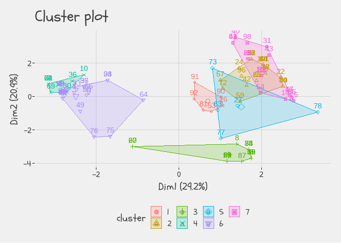

```r
zoo.kmeans <- kmeans(zoo_X, 7)
fviz_cluster(zoo.kmeans, data = zoo_X, ggtheme = theme_fivethirtyeight())+
  theme(axis.title = element_text(), text = element_text(family = "bell", size = 15))
```

```r
zoo.kmeans.clusters <- zoo.kmeans$cluster
confusion.kmeans <- table(zoo.kmeans.clusters, zoo_y[, 1])
acc_kmeans <- sum(diag(confusion.kmeans)) / sum(confusion.kmeans)
precison_kmeans <- diag(confusion.kmeans) / rowSums(confusion.kmeans)
recall_kmeans <- diag(confusion.kmeans) / colSums(confusion.kmeans)
```

#### We can see immediately from the plot that ourK Means model will have some difficulties because some groups overlaps (2, 5, 7)

### Hierarchical Clustering

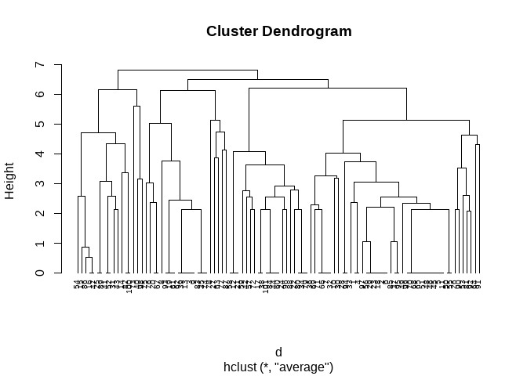

```r
d <- dist(zoo, method = "euclidean")
zoo.hc <- hclust(d, method = "average")
plot(zoo.hc, cex=0.6, hang = -1)
```

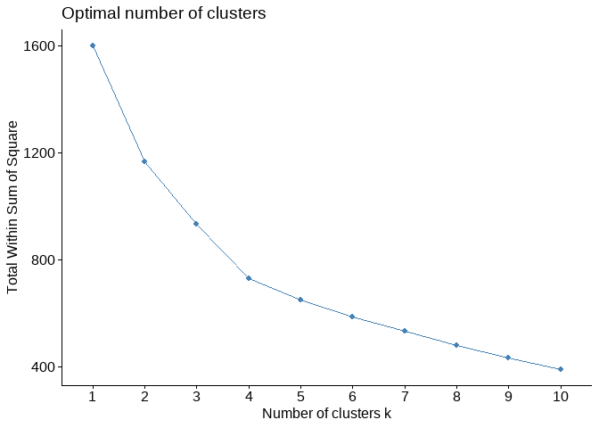

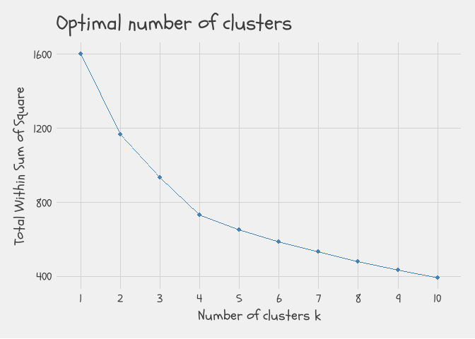

```r
plot(plot(fviz_nbclust(zoo_X, FUN = hcut, method = "wss"))+
  theme_fivethirtyeight()+
  theme(axis.title = element_text(), text = element_text(family = "bell", size = 15)))
```

#### The hierarchical model doesn’t really seem to be able to separate well the data neither. By looking at the elbow plot we could try to choose between 4 and 6 clusters, but we know that we have 7 different classes, so we will chose 7 clusters.

```r
zoo.hc.predicted <- cutree(zoo.hc, k=7, h=5)
confusion.hc <- table(zoo.hc.predicted, zoo_y[, 1])
acc_hc <- sum(diag(confusion.hc)) / sum(confusion.hc)
precison_hc <- diag(confusion.hc) / rowSums(confusion.hc)
recall_hc <- diag(confusion.hc) / colSums(confusion.hc)
```

#### Performance comparison between K Means and Hierarchical Clustering

```r
comparison.accuracy <- t(data.frame(acc_kmeans, acc_hc))
colnames(comparison.accuracy) <- "Accuracy"
comparison.precision <- t(data.frame(precison_kmeans, precison_hc))
comparison.recall <- t(data.frame(recall_kmeans, recall_hc))
knitr::kable(comparison.accuracy, format = "markdown")
```

|  | Accuracy |
| --- | --- |
| acc_kmeans | 0.5544554 |
| acc_hc | 0.0396040 |

```r
knitr::kable(comparison.precision, format = "markdown")
```

|  | 1 | 2 | 3 | 4 | 5 | 6 | 7 |
| --- | --- | --- | --- | --- | --- | --- | --- |
| precison_kmeans | 0.5000000 | 1 | 0 | 0 | 0.4 | 1 | 0 |
| precison_hc | 0.0697674 | 0 | 0 | 0 | 0.2 | 0 | 0 |

```r
knitr::kable(comparison.recall, format = "markdown")
```

|  | Amphibian | Bird | Bug | Fish | Invertebrate | Mammal | Reptile |
| --- | --- | --- | --- | --- | --- | --- | --- |
| recall_kmeans | 0.75 | 1 | 0 | 0 | 0.2 | 0.7560976 | 0 |
| recall_hc | 0.75 | 0 | 0 | 0 | 0.1 | 0.0000000 | 0 |

#### We can easily say that K Means Clustering outperforms Hierarchical Clustering in accuracy, precision and recall.

#### It’s better to use Hiearchical clustering algorithm if we don’t know the number of classes that our dataset has.